# README.Rmd

#Preguntas

##a. Examine the portion of the script you see below. In your own words what does this section do and why does it work? vonset = Get starting point: 2, 2: the point when the vowel starts voffset = Get end point: 2, 2: the points when the vowel ends durationV = voffset - vonset: vowel duration is the final of the vowel less the onset of the vowel per20 = vonset + (durationV * 0.20): is the 20% of the total vowel duration per35 = vonset + (durationV * 0.35): is the 35% of the total vowel duration per50 = vonset + (durationV * 0.50): is the 50% of the total vowel duration per65 = vonset + (durationV * 0.65): is the 65% of the total vowel duration per80 = vonset + (durationV * 0.80): is the 80% of the total vowel duration

cargar base de datos

```r
library(tidyverse)
df1 = read_csv("data/vowel_data.csv")
```

Manipulate the dataframe as necessary so that you can calculate average F1/F2 centroids and trajectory length (include SD).

media y SD de las variables

```r
df1 %>%
    summarise(media_f1 = mean(f1_cent), sd_f1 = sd(f1_cent), media_f2 = mean(f2_cent), sd_f2 = sd(f2_cent),  meadia_tl = mean(tl), sd_tl = sd(tl))
```

```
## # A tibble: 1 x 6
##   media_f1 sd_f1 media_f2 sd_f2 meadia_tl sd_tl
##      <dbl> <dbl>    <dbl> <dbl>     <dbl> <dbl>
## 1     581.  278.    1547.  498.     1144. 1119.
```

trajectory length as a function of vowel and language

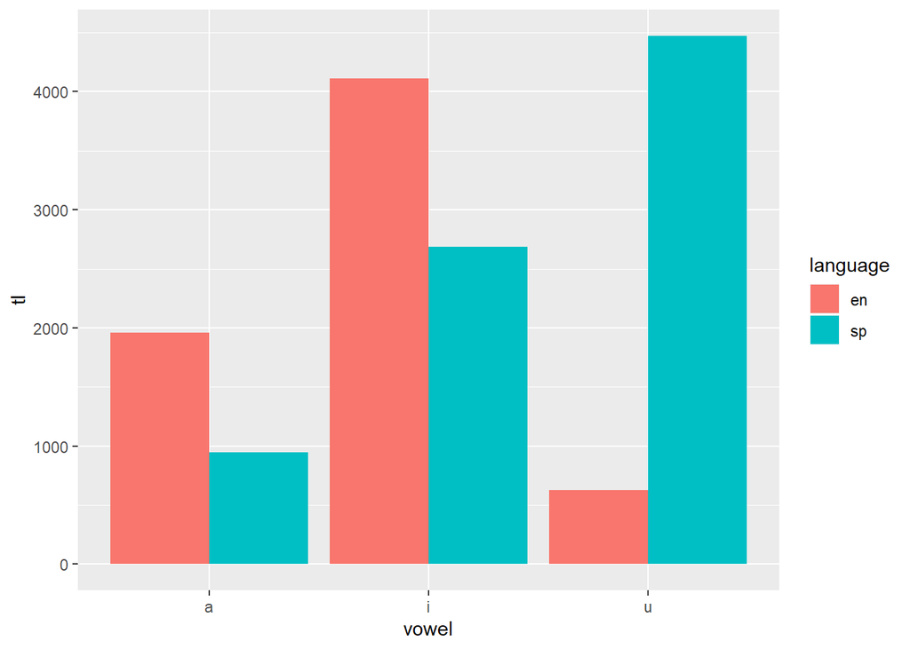

```r
  ggplot(df1, aes(fill= language, y=tl, x=vowel)) +
  geom_bar(position="dodge", stat="identity")
```

F1 as a function of vowel and language

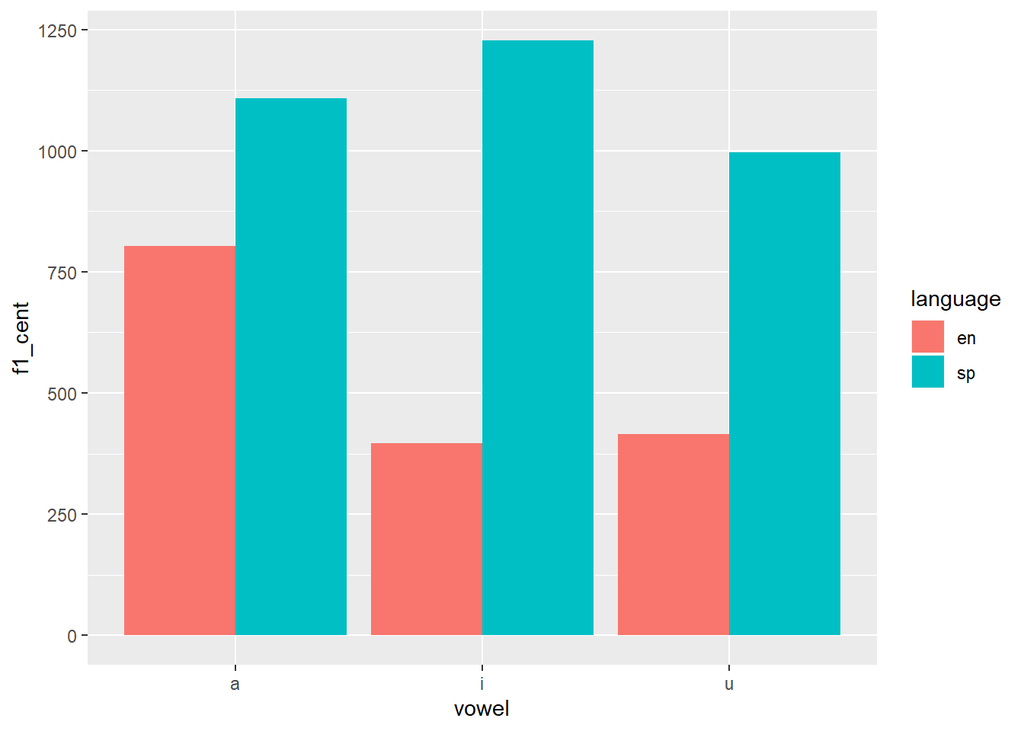

```r
ggplot(df1, aes(fill= language, y=f1_cent, x=vowel)) +
  geom_bar(position="dodge", stat="identity")
```

F2 as a function of vowel and language

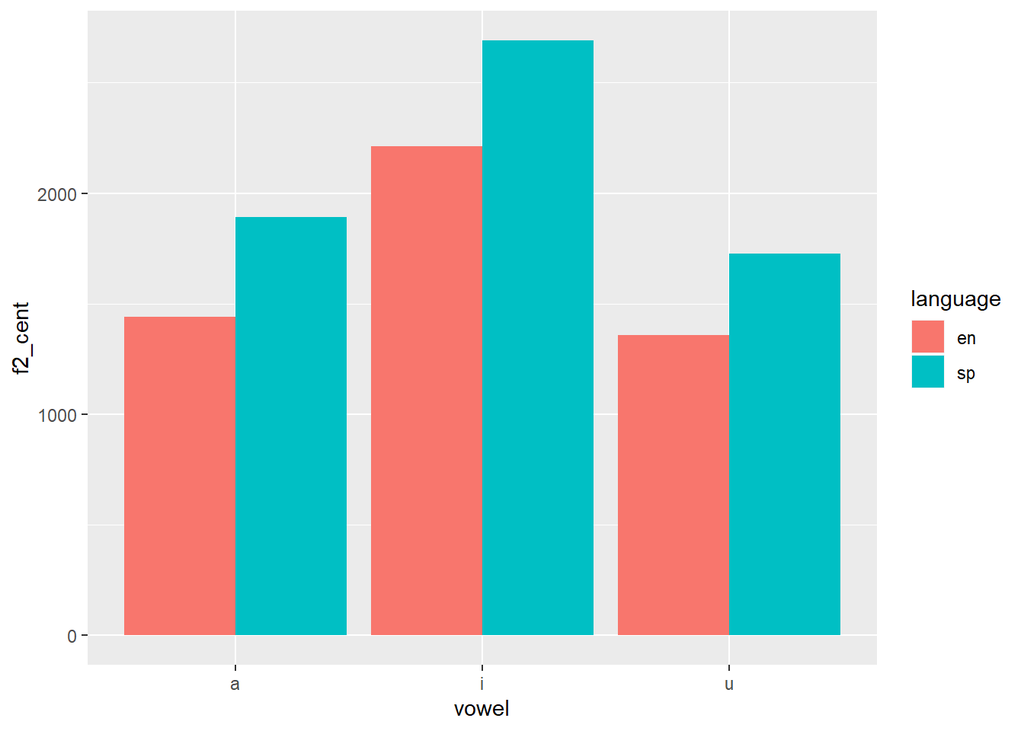

```r
ggplot(df1, aes(fill= language, y=f2_cent, x=vowel)) +
  geom_bar(position="dodge", stat="identity")
```